# HSC Survey Results

# German Bank Survey # 2 Results from 24/08/2026

## Survey Details

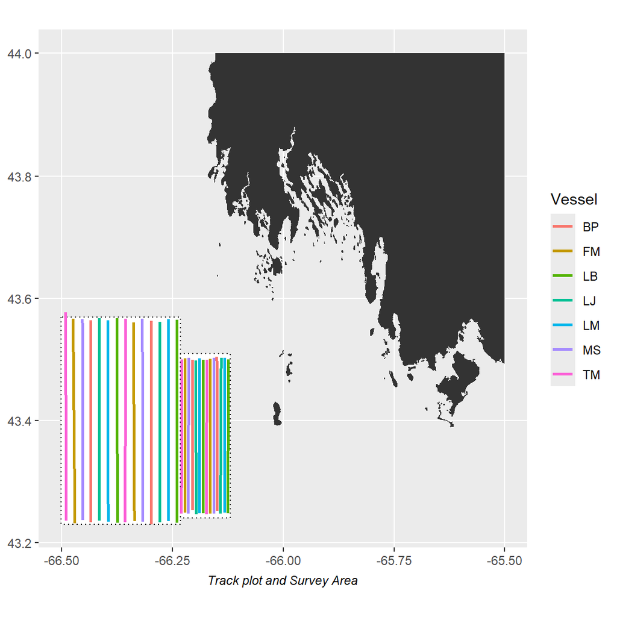

7 commercial purse seiners conducted this fishing survey on 24/08/2026 starting at 20:30:00.

All vessels ran two transects in the German Bank box and two transect in the Seal Island Box.

There was a plankton tow and replicate conducted and CTD cast by Leroy and Barry.

No tags were applied during this survey.

Samples were obtained for target strength estimation.

### Acoustic Equipment

Each vessel was equipped with a Simrad ES38-18/200-18C combi (2-in-1) transducer prior to the survey that contains a 38kHz split beam and 200 kHz single beam transducer. Data was logged to the computer hard-drive for post-processing. All participating boats were calibrated on 38kHz before the survey.

## Survey Results

### Main Results

The results are subject to change as DFO will re-evaluate data editing, area estimation and apply a target strength.

**Preliminary biomass prediction for German Bank using standardized parallel transects is 23,002mt, and with turnover applied 19,220mt. The preliminary biomass estimate for Seal Island is 4,584mt.**

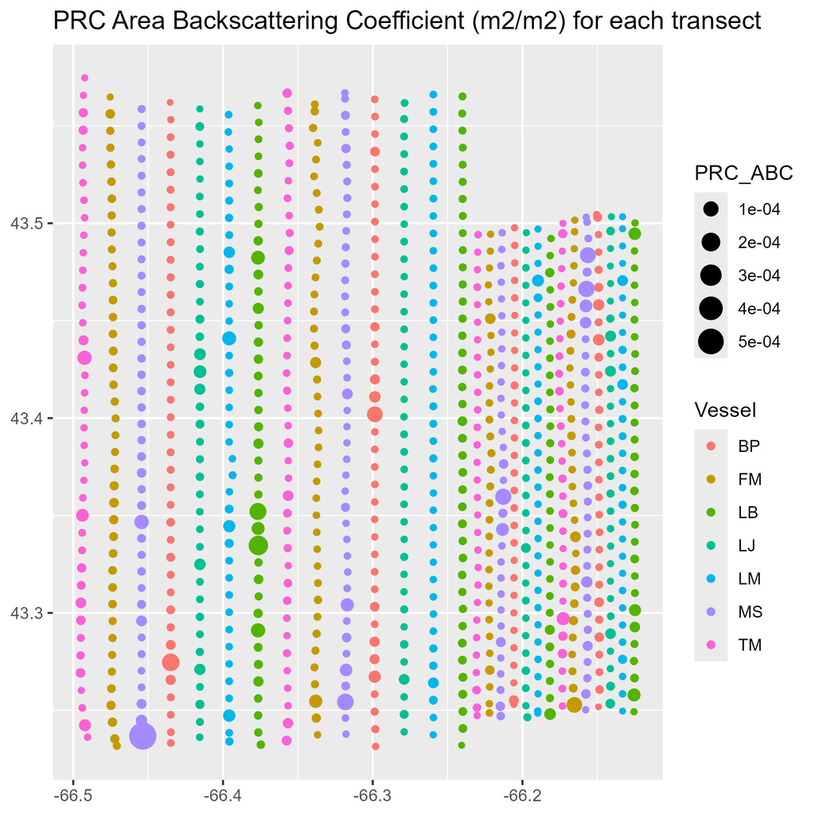

### Transect Details

Table 1: Transect Details

| Vessel | Transect # | Date/Time Start | Date/Time End | Start Lon | Start Lat | End Lon | End Lat | Location | Distance (km) | Speed |
| --- | --- | --- | --- | --- | --- | --- | --- | --- | --- | --- |
| BP | T01 | 2026-08-24 19:49:19 | 2026-08-24 22:18:39 | -66.436 | 43.565 | -66.435 | 43.233 | GB | 36.90 | 8.00 |
| BP | T02 | 2026-08-24 22:56:16 | 2026-08-25 01:27:48 | -66.299 | 43.230 | -66.299 | 43.564 | GB | 37.18 | 7.95 |
| BP | T03 | 2026-08-25 02:01:52 | 2026-08-25 03:47:01 | -66.205 | 43.500 | -66.206 | 43.253 | GB | 27.49 | 8.47 |
| BP | T04 | 2026-08-25 04:03:47 | 2026-08-25 05:39:13 | -66.149 | 43.252 | -66.150 | 43.504 | GB | 28.17 | 9.56 |
| FM | T01 | 2026-08-24 21:08:53 | 2026-08-24 23:35:55 | -66.475 | 43.567 | -66.471 | 43.232 | GB | 38.72 | 8.53 |
| FM | T02 | 2026-08-25 00:10:34 | 2026-08-25 02:37:20 | -66.336 | 43.235 | -66.339 | 43.561 | GB | 37.68 | 8.32 |
| FM | T03 | 2026-08-25 03:12:25 | 2026-08-25 05:08:16 | -66.223 | 43.502 | -66.222 | 43.249 | GB | 29.45 | 8.23 |
| FM | T04 | 2026-08-25 05:24:35 | 2026-08-25 07:10:37 | -66.166 | 43.247 | -66.165 | 43.502 | GB | 29.33 | 8.96 |
| LB | T01 | 2026-08-24 19:55:13 | 2026-08-24 22:33:16 | -66.376 | 43.568 | -66.375 | 43.232 | GB | 38.70 | 7.93 |
| LB | T02 | 2026-08-24 23:14:29 | 2026-08-25 01:42:35 | -66.241 | 43.232 | -66.240 | 43.565 | GB | 38.05 | 8.32 |
| LB | T03 | 2026-08-25 02:12:15 | 2026-08-25 03:55:39 | -66.182 | 43.500 | -66.182 | 43.248 | GB | 28.79 | 9.02 |
| LB | T04 | 2026-08-25 04:15:36 | 2026-08-25 05:54:28 | -66.125 | 43.248 | -66.125 | 43.500 | GB | 28.78 | 9.43 |
| LJ | T01 | 2026-08-24 20:18:07 | 2026-08-24 22:43:22 | -66.415 | 43.568 | -66.416 | 43.236 | GB | 36.88 | 8.22 |
| LJ | T02 | 2026-08-24 23:21:30 | 2026-08-25 01:41:11 | -66.279 | 43.234 | -66.279 | 43.562 | GB | 36.52 | 8.47 |
| LJ | T03 | 2026-08-25 02:09:43 | 2026-08-25 04:01:58 | -66.199 | 43.499 | -66.197 | 43.246 | GB | 28.12 | 8.12 |
| LJ | T04 | 2026-08-25 04:17:50 | 2026-08-25 06:06:11 | -66.142 | 43.247 | -66.141 | 43.503 | GB | 28.57 | 8.54 |
| LM | T01 | 2026-08-24 20:19:03 | 2026-08-24 22:44:59 | -66.397 | 43.564 | -66.396 | 43.234 | GB | 37.51 | 8.33 |
| LM | T02 | 2026-08-24 23:19:15 | 2026-08-25 01:42:36 | -66.260 | 43.235 | -66.260 | 43.566 | GB | 37.34 | 8.44 |
| LM | T03 | 2026-08-25 02:08:51 | 2026-08-25 03:59:17 | -66.190 | 43.502 | -66.190 | 43.249 | GB | 28.72 | 8.42 |
| LM | T04 | 2026-08-25 04:15:27 | 2026-08-25 05:59:49 | -66.133 | 43.249 | -66.133 | 43.503 | GB | 28.75 | 8.93 |
| MS | T01 | 2026-08-24 21:10:42 | 2026-08-24 23:30:15 | -66.454 | 43.567 | -66.453 | 43.237 | GB | 38.99 | 9.05 |
| MS | T02 | 2026-08-25 00:07:38 | 2026-08-25 02:37:41 | -66.317 | 43.234 | -66.319 | 43.567 | GB | 39.83 | 8.60 |
| MS | T03 | 2026-08-25 03:12:46 | 2026-08-25 05:09:29 | -66.214 | 43.503 | -66.214 | 43.247 | GB | 30.60 | 8.49 |
| MS | T04 | 2026-08-25 05:28:00 | 2026-08-25 07:07:08 | -66.157 | 43.247 | -66.157 | 43.503 | GB | 30.73 | 10.04 |
| TM | T01 | 2026-08-24 19:52:28 | 2026-08-24 22:30:15 | -66.492 | 43.577 | -66.490 | 43.236 | GB | 38.02 | 7.81 |
| TM | T02 | 2026-08-24 23:05:59 | 2026-08-25 01:35:20 | -66.357 | 43.233 | -66.357 | 43.567 | GB | 37.22 | 8.07 |
| TM | T03 | 2026-08-25 02:15:36 | 2026-08-25 04:03:20 | -66.230 | 43.500 | -66.230 | 43.247 | GB | 28.11 | 8.45 |
| TM | T04 | 2026-08-25 04:21:59 | 2026-08-25 06:08:58 | -66.174 | 43.246 | -66.173 | 43.500 | GB | 28.27 | 8.56 |

### Survey Summary

Table 2: Acoustic Survey Results

| Vessel | Transect No. | Target Strength (db/kg) | Mean Sa (/m2) | Biomass Density (kg/m2) |
| --- | --- | --- | --- | --- |
| MS | T01 | -35.5 | -46.616 | 0.077 |
| LB | T01 | -35.5 | -46.984 | 0.071 |
| MS | T04 | -35.5 | -48.544 | 0.050 |
| MS | T02 | -35.5 | -50.510 | 0.032 |
| MS | T03 | -35.5 | -50.894 | 0.029 |
| BP | T02 | -35.5 | -50.931 | 0.029 |
| LB | T04 | -35.5 | -51.020 | 0.028 |
| FM | T04 | -35.5 | -51.372 | 0.026 |
| TM | T01 | -35.5 | -51.440 | 0.025 |
| BP | T01 | -35.5 | -51.457 | 0.025 |
| LJ | T01 | -35.5 | -51.581 | 0.025 |
| LM | T01 | -35.5 | -51.631 | 0.024 |
| FM | T01 | -35.5 | -52.748 | 0.019 |
| BP | T04 | -35.5 | -53.087 | 0.017 |
| FM | T02 | -35.5 | -53.492 | 0.016 |
| TM | T04 | -35.5 | -53.645 | 0.015 |
| LB | T02 | -35.5 | -53.702 | 0.015 |
| LJ | T04 | -35.5 | -54.056 | 0.014 |
| TM | T02 | -35.5 | -54.415 | 0.013 |
| LB | T03 | -35.5 | -54.475 | 0.013 |
| LM | T04 | -35.5 | -55.864 | 0.009 |
| LM | T03 | -35.5 | -56.602 | 0.008 |
| FM | T03 | -35.5 | -56.650 | 0.008 |
| LJ | T02 | -35.5 | -56.695 | 0.008 |
| LM | T02 | -35.5 | -56.862 | 0.007 |
| LJ | T03 | -35.5 | -57.935 | 0.006 |
| BP | T03 | -35.5 | -58.916 | 0.005 |
| TM | T03 | -35.5 | -60.144 | 0.003 |

Note:  
Transects are listed from greatest to least backscatter.

Table 3: Survey Summary Table

| Layer | Target Strength | Area (km2) | Mean Sa | Density (kg/m2) | Biomass (tons) | Percent Area | Percent Biomass | Standard Error (tons) | Standard Error (%) |
| --- | --- | --- | --- | --- | --- | --- | --- | --- | --- |
| German Bank | -35.5 | 826 | -51.0522 | 0.0276 | 23,001.855 | 75.1 | 83.4 | 4,666.20 | 20.29 |
| Seal Island | -35.5 | 274 | -53.2648 | 0.0164 | 4,584.286 | 24.9 | 16.6 | 937.85 | 20.46 |

### Greatest Biomass Densities

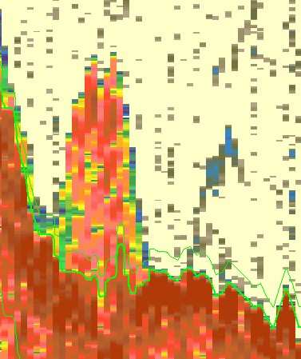

A snip from the transect with the greatest biomass density (kg/m2)

The single point with the largest biomass density (kg/m2) was recorded by **MS**, at the following location:

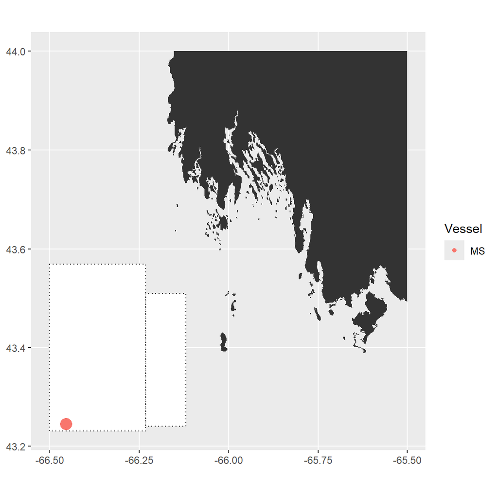

The transect with the greatest average biomass density (kg/m2) was recorded by **MS**, at the following location:

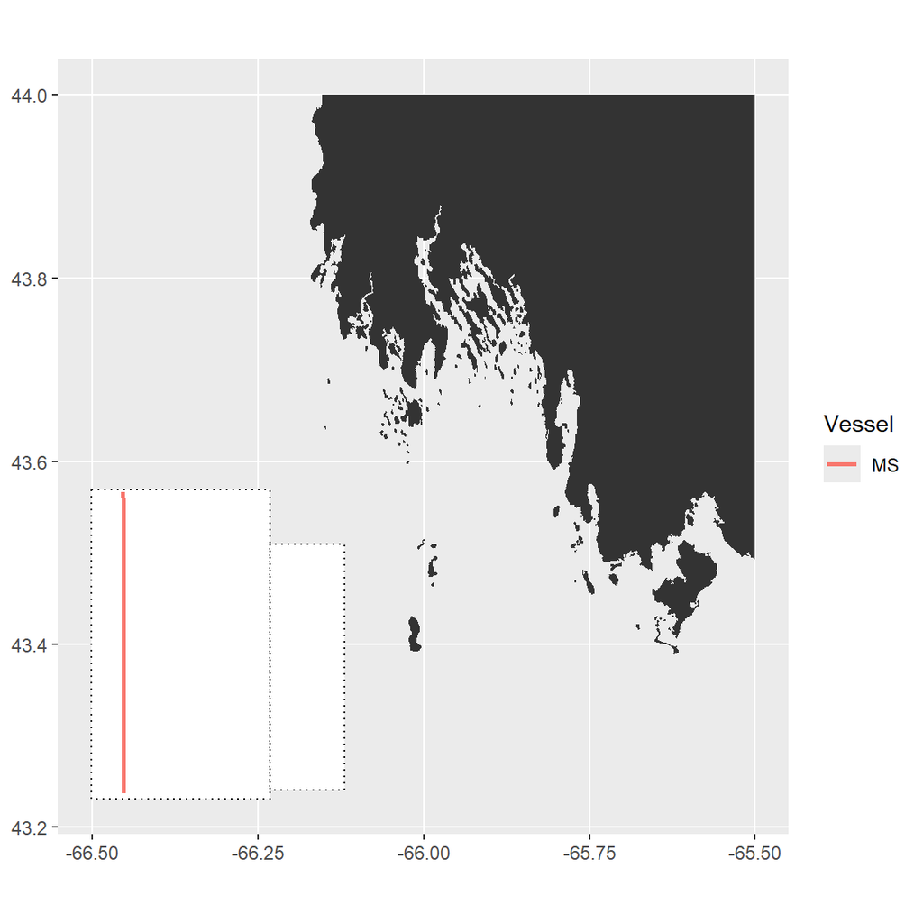

### Annual Summaries

This table does not include the biomass from adhoc surveys.

Table 4: Annual Comparison Table

| Ground | Survey Number | Current Year Survey Date | Current Year HSC Estimate | Current Year HSC Turnover Adjusted | Previous Year Survey Date | Previous Year HSC Estimate | Previous Year HSC Turnover Adjusted | Previous Year DFO Estimate | Previous Year DFO Turnover Adjusted |
| --- | --- | --- | --- | --- | --- | --- | --- | --- | --- |
| German Bank | 1 | 2026-08-09 | 51,965.016 | 51,965.02 | 2025-08-04 | 6,194 | 6,194 | NA | NA |
| Seal Island | 1 | 2026-08-09 | 7,023.005 | NA | 2025-08-04 | 1,160 | NA | NA | NA |
| German Bank | 2 | 2026-08-24 | 23,001.855 | 19,220.00 | 2025-08-18 | 35,008 | 32,592 | NA | NA |
| Seal Island | 2 | 2026-08-24 | 4,584.286 | NA | 2025-08-18 | 6,220 | NA | NA | NA |
| German Bank | 3 | NA | NA | NA | 2025-08-31 | 30,892 | 21,986 | NA | NA |
| Seal Island | 3 | NA | NA | NA | 2025-08-31 | 6,500 | NA | NA | NA |
| German Bank | 4 | NA | NA | NA | 2025-09-14 | 15,323 | 7,753 | NA | NA |
| Seal Island | 4 | NA | NA | NA | 2025-09-14 | 18,112 | NA | NA | NA |
| German Bank | 5 | NA | NA | NA | 2025-09-28 | 6,754 | 2,138 | NA | NA |
| Seal Island | 5 | NA | NA | NA | 2025-09-28 | 5,048 | NA | NA | NA |
| German Bank | 6 | NA | NA | NA | 2025-10-14 | 8,611 | 7,291 | NA | NA |
| Seal Island | 6 | NA | NA | NA | 2025-10-14 | 10,346 | NA | NA | NA |
| German Bank | 7 | NA | NA | NA | 2025-10-26 | 20,039 | 17,877 | NA | NA |
| Seal Island | 7 | NA | NA | NA | 2025-10-26 | 3,433 | NA | NA | NA |

Table 5: Annual Summary Table

| Year | Ground | HSC Estimate | HSC Turnover Adjusted | DFO Estimate | DFO Turnover Adjusted |
| --- | --- | --- | --- | --- | --- |
| 2025 | German Bank | 122,821.00 | 95,831.00 | NA | NA |
| 2025 | Seal Island | 50,819.00 | NA | NA | NA |
| 2026 | German Bank | 74,966.87 | 71,185.02 | NA | NA |
| 2026 | Seal Island | 11,607.29 | NA | NA | NA |

## Vessel Performance

### Speed

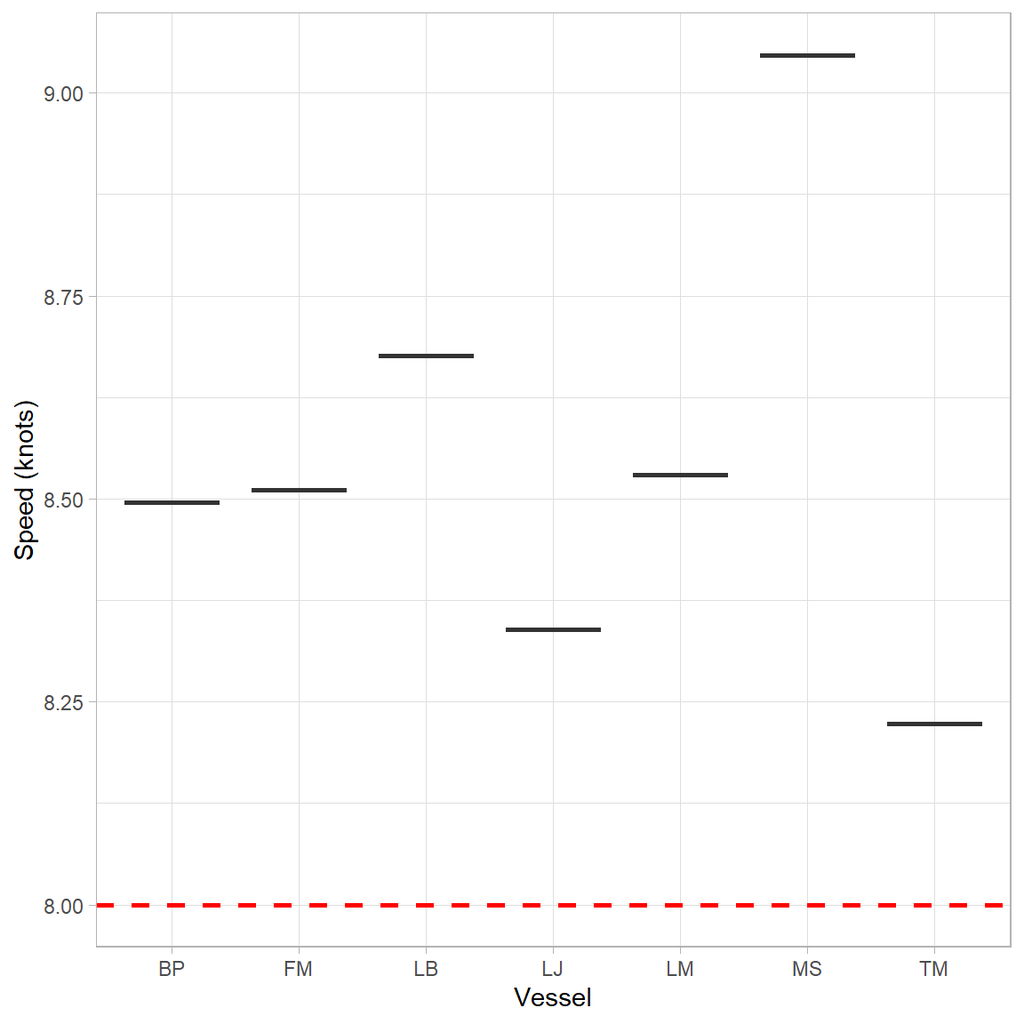

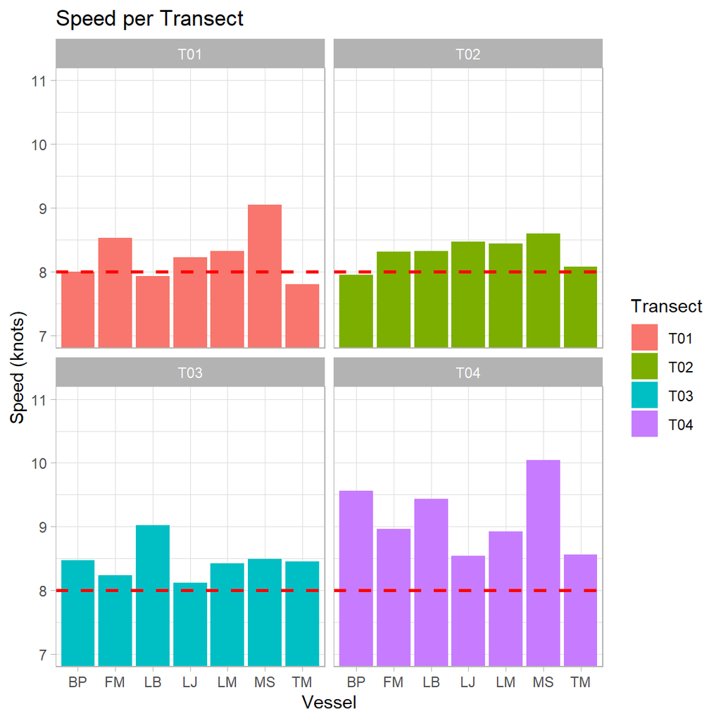

Average vessel speed was 8.55. This is above the 8 knot requirement; vessels are urged to slow down to prevent backscatter noise from interfering with the acoustic data.

The speed for each transect are rudimentary and are calculated based on distance. If a significant amount of distance is cut, the speed will appear slower.